# Curso R - UCE

14 Octubre de 2020

## **Interfaz de RStudio**

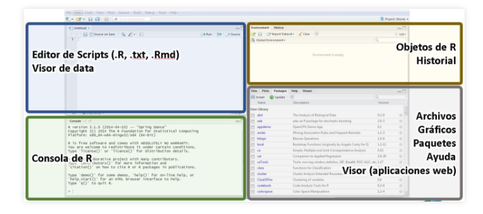

## **Ejecutar código R**

- **R como calculadora**

```r
  5+10
```

```
## [1] 15
```

```r
  8/20
```

```
## [1] 0.4
```

```r
  sin(10)
```

```
## [1] -0.5440211
```

## **Instalación de paquetes**

- Utilizamos la función (install.packages).
- Se indica el nombre del paquete.

```r
  install.packages("package_name")
```

- Se indica si se deben instalar o no los paquetes requeridos para que este funcione.

```r
  install.packages("package_name", dependencies=TRUE)
```

- En el caso que se desee instalar un lista de n paquetes planteamos la siguiente solución:

```r
  packages <- c("package_1","package_2", ... , "package_n")
  install.packages(packages, dependencies=TRUE)
  # funciones apply
  # sapply(X=packages, FUN=install.packages, dependencies=TRUE)
```

## **Ejemplo**

- Instalar el paquete **tidyverse**

```r
  install.packages("tidyverse", dependencies=TRUE)
```

- Instalar varios paquetes a la vez

[figure not shown]

```r
  packages <- c("ggplot2","lubridate","readr")
  install.packages(packages, dependencies=TRUE)
  # funciones apply
  # sapply(X=packages, FUN=install.packages, dependencies=TRUE)
```

## **Cargar paquetes**

- La función **library** o **require** nos permite cargar un paquete al área de trabajo.
- Lo paquetes se instalan una sola vez y serán cargados cada vez que se inicie una nueva sección.

```r
  library(ggplot2)
```

- Cargar varios paquetes

```r
  packages <- c("ggplot2","lubridate","readr")
  # funciones apply
  # sapply(X=packages, FUN=library, character.only=TRUE)
```

- Conocer que paquetes están cargados

```r
  (.packages())
```

```
## [1] "ggplot2"   "stats"     "graphics"  "grDevices" "utils"     "datasets"
## [7] "methods"   "base"
```

## **Estructura de Datos Fundamentales**

La estructura de los datos se organizan por:

- **Dimensionalidad**
- **Homogeneidad o heterogeneidad**

| N° Dimensiones | Simple | Multiple |
| --- | --- | --- |
| 1 Dimensión | Vector | List |
| 2 Dimensiones | Matrix | Dataframe |
| n Dimensiones | Array |  |

## **Generalidades**

- Nuevo script: ctrl + shift + n
- Ejecutar selección o linea actual: ctrl + enter
- Insertar simbolo de asignación **<-**: alt + -

```r
  a <- 5
```

- Comentar/descomentar: ctrl + shift + c

```r
  # Este es un comentario
```

- Crear secciones de código: ctrl + shift + r
- Insertar el operador pipe **%>%**: ctrl + shift + m

```r
  df %>% select(variable)
```

## **Vectores**

- La estructura de datos básica de R son los vectores, estos se dividen en:
  - **Vectores atómicos y Listas**
- Presentan tres propiedades comunes:
  - Tipo (Qué es?). `typeof()`
  - Longitud (Número de elementos) `length()`
  - Atributos (Metadata). `attributes()`
- Para probar que una estructura de datos es un vector (atómico o lista) se utiliza la función:

```r
  is.vector(x)
```

- `is.vector(x)` retorna `TRUE` si `x` es un vector atómico o una lista.

## **Vectores atómicos**

- Los elementos de un vector atómico son del **mismo tipo** (tipos comunes):
  - logical
  - integer
  - double (comunmente llamados numeric)
  - character
- Un vector es creado mediante la función `c()`, e ingresamos a la *i-ésima* componente con `x[i]`

```r
  dbl_var <- c(1, 2, -1)
  int_var <- c(3L, 7L, 1L) # con el sufijo L se declaran números enteros
  log_var <- c(FALSE, TRUE, F, T) # TRUE y FALSE (T, F) se usan para crear vectores lógicos
  chr_var <- c("Source", "Stat", "Lab")
```

```r
  # tercera componente de dbl_var
  dbl_var[3]
```

[output not shown]

```r
  c(1, c(2, c(3,4))) ; c(1, 2, 3, 4) # los vectores pueden ser anidados
```

```
## [1] 1 2 3 4
```

```
## [1] 1 2 3 4
```

## **Tipos de Vectores atómicos**

- Dado un vector se puede determinar su tipo con `typeof()` o verificar un tipo específico con una “is” función:
  - `is.character()`
  - `is.double()`
  - `is.integer()`
  - `is.logical()`

```r
  dbl_var <- c(1, 2, -1)
  typeof(dbl_var)
```

```
## [1] "double"
```

```r
  is.double(dbl_var)
```

```
## [1] TRUE
```

## **Tipos de Vectores atómicos**

```r
  dbl_var <- c(1, 2, -1)
  is.atomic(dbl_var)
```

```
## [1] TRUE
```

```r
  int_var <- c(3L, 7L, 1L)
  typeof(int_var)
```

```
## [1] "integer"
```

```r
  is.integer(int_var)
```

```
## [1] TRUE
```

```r
  is.atomic(int_var)
```

```
## [1] TRUE
```

## **Tipos de Vectores atómicos**

- **`is.numeric()` retorna `TRUE` para vectores double e integer**

```r
  dbl_var <- c(1, 2, -1)
  is.numeric(dbl_var)
```

```
## [1] TRUE
```

```r
  int_var <- c(3L, 7L, 1L)
  is.numeric(int_var)
```

```
## [1] TRUE
```

## **Coerción**

- Los elementos de un vector son del mismo tipo, es por eso que si combinamos tipos diferentes, serán coercionados al tipo más flexible dado por la jerarquía:

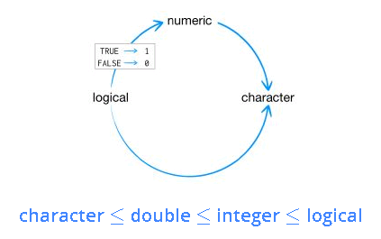

```r
  x <- c("Hola", 1, TRUE)
  typeof(x)
```

```
## [1] "character"
```

## **Coerción**

- Se usa las funciones **“as”** para coercionar un vector a un determinado tipo: `as.character(), as.double(), as.integer(), as.logical()`

```r
  x <- c(FALSE, TRUE, FALSE, TRUE)
  as.numeric(x) # TRUE coerciona a 1 y FALSE a 0
```

```
## [1] 0 1 0 1
```

```r
  sum(x) # número total de TRUEs
```

```
## [1] 2
```

```r
  mean(x) # proporción de TRUEs
```

```
## [1] 0.5
```

## **Listas**

- Una lista puede contener elementos de cualquier tipo.
- Para construir una lista se utiliza la función `list()` en lugar de `c()`.

```r
  x <- list(1:3, c("Source", "Stat", "Lab"), c(TRUE, FALSE), c(1.3, 4.5))
  str(x)
```

```
## List of 4
##  $ : int [1:3] 1 2 3
##  $ : chr [1:3] "Source" "Stat" "Lab"
##  $ : logi [1:2] TRUE FALSE
##  $ : num [1:2] 1.3 4.5
```

```r
  is.atomic(x)
```

```
## [1] FALSE
```

```r
  # coercionamos un objeto a una lista
  as.list(c("Hola", 4, 0.5))
```

[output not shown]

## **Listas**

```r
  x <- list(1:3, c("Source", "Stat", "Lab"), c(TRUE, FALSE), c(1.3, 4.5))
  typeof(x)
```

```
## [1] "list"
```

```r
  # probamos si x es una lista
  is.list(x)
```

```
## [1] TRUE
```

```r
  # pasamos a vector considerando las reglas de coerción
  unlist(x)
```

```
##  [1] "1"      "2"      "3"      "Source" "Stat"   "Lab"    "TRUE"   "FALSE"
##  [9] "1.3"    "4.5"
```

## **Listas**

- Una lista es un **vector recursivo**, es decir una lista puede contener otra lista (diferencia principal con los **vectores atómicos**)

```r
  x <- list(list(list("Source", "Stat")))
  str(x)
```

```
## List of 1
##  $ :List of 1
##   ..$ :List of 2
##   .. ..$ : chr "Source"
##   .. ..$ : chr "Stat"
```

```r
  # son equivalentes. un vector no puede contener otro vector
  c(1, c(2, c(3,4)))  ;  c(1, 2, 3, 4)
```

```
## [1] 1 2 3 4
```

```
## [1] 1 2 3 4
```

## **Elementos de una lista**

- Para acceder al elemento `i` de la lista se utiliza `x[i]`, en cambio para acceder al objeto que contiene el elemento `i` se utiliza `x[[i]]` o `x$nomb_obj`.

```r
  x <- list(1:3, c("Source", "Stat", "Lab"), nomb_obj=c(TRUE, FALSE), c(1.3, 4.5))
  x[4]
```

```
## [[1]]
## [1] 1.3 4.5
```

```r
  x[[4]]
```

```
## [1] 1.3 4.5
```

```r
  x$nomb_obj
```

```
## [1]  TRUE FALSE
```

## **Matrices**

Una matriz es un vector con el atributo dimensión dim. El atributo dim es un vector de longitud 2:c(nrow, ncol). Se construye por columnas por defecto (byrow=FALSE).

```r
  mtx <- matrix (1:12,nrow=3, ncol=4, byrow=FALSE)
  mtx
```

```
##      [,1] [,2] [,3] [,4]
## [1,]    1    4    7   10
## [2,]    2    5    8   11
## [3,]    3    6    9   12
```

```r
  mtx <- matrix (1:12,nrow=3, ncol=4, byrow=TRUE)
  mtx
```

```
##      [,1] [,2] [,3] [,4]
## [1,]    1    2    3    4
## [2,]    5    6    7    8
## [3,]    9   10   11   12
```

## **Elementos de una matriz**

Columnas dos y cuatro

```r
  mtx <- matrix (1:12, nrow=3, ncol=4, byrow=FALSE)
  mtx[,c(2,4)]
```

```
##      [,1] [,2]
## [1,]    4   10
## [2,]    5   11
## [3,]    6   12
```

```r
  # Filas 2 y 3
  mtx[c(2,3),]
```

```
##      [,1] [,2] [,3] [,4]
## [1,]    2    5    8   11
## [2,]    3    6    9   12
```

## **Array**

Un array es la generalización de una matriz de dos dimensiones al caso multidimensional. Su definición general es de la forma:

- array(datos, dimensiones)

```r
  array(1:12,c(2,3,2))
```

```
## , , 1
##
##      [,1] [,2] [,3]
## [1,]    1    3    5
## [2,]    2    4    6
##
## , , 2
##
##      [,1] [,2] [,3]
## [1,]    7    9   11
## [2,]    8   10   12
```

## **Array**

Un ejemplo más ilustrativo:

Vamos a crear un array con la edad media, el peso medio y la estatura media para hombres y mujeres de dos poblaciones: Sur y Norte:

```r
  x<-array(c(45,46,65,55,170,167,48,49,68,56,169,165),c(2,3,2))
  dimnames(x)<-list(c("hombres","mujeres"),c("edad","peso","altura"),c("Sur","Norte"))
  x
```

```
## , , Sur
##
##         edad peso altura
## hombres   45   65    170
## mujeres   46   55    167
##
## , , Norte
##
##         edad peso altura
## hombres   48   68    169
## mujeres   49   56    165
```

## **Elementos de un array**

Para acceder a los elementos del array:

```r
  dimnames(x)# Nombre de las dimensiones del array
```

```
## [[1]]
## [1] "hombres" "mujeres"
##
## [[2]]
## [1] "edad"   "peso"   "altura"
##
## [[3]]
## [1] "Sur"   "Norte"
```

```r
  x[,,"Sur"] # Datos para la población "Sur"
```

```
##         edad peso altura
## hombres   45   65    170
## mujeres   46   55    167
```

## **Dataframe**

- Es una lista en la cual todos los elementos tienen la misma longitud.
- A diferencia de las matrices, pueden almacenar vectores atómicos de cualquier tipo.
- Presenta varios atributos adicionales class, rownames, names.
- Es la estructura de datos más utilizada para almacenar data tabulada.

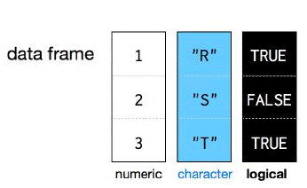

## **Dataframe**

- Para crear un data frame se utiliza la función data.frame(). Con los siguientes vectores atómicos:

```r
  dbl_vec <- c(1, 2, 3)
  chr_vec <- c("R", "S", "T")
  log_vec <- c(TRUE, FALSE, TRUE)
```

Creamos el data frame df:

```r
  df <- data.frame(dbl_vec, chr_vec, log_vec)
  df
```

```
##   dbl_vec chr_vec log_vec
## 1       1       R    TRUE
## 2       2       S   FALSE
## 3       3       T    TRUE
```

## **Elementos de un dataframe**

- Para crear un data frame se utiliza la función data.frame(). Con los siguientes vectores atómicos:

```r
  nomb <- c("John", "Paul", "George", "Ringo")
  nac <- c(1940, 1941, 1943, 1940)
  instr <- c("guitar", "bass", "guitar", "drums")
  df <- data.frame(nomb, nac, instr)
  df[2, c(2,3)] #Mediante df[i, j] se obtiene la componente i, j del data frame.
```

```
##    nac instr
## 2 1941  bass
```

## **Elementos de un dataframe**

```r
  df[2, 2] # componente 2, 2
```

```
## [1] 1941
```

```r
  df[3, 1] # componente 3, 1
```

```
## [1] "George"
```

```r
  df[3, ] # fila 3
```

```
##     nomb  nac  instr
## 3 George 1943 guitar
```

```r
  df[ , 3]=="guitar" # columna 3 de df igual a "guitar"
```

```
## [1]  TRUE FALSE  TRUE FALSE
```